# Teaching AI for the Disciplines: PrAxIs at UBC

Disciplinary AI literacy for Arts and Social Science

Jonathan Graves

Vancouver School of Economics, UBC

Laura Nelson

Department of Sociology & CCSS, UBC

May 28, 2026

[figure not shown]

ubcecon.github.io/praxis-ubc

The Praxis Project and UBC are located on the traditional, ancestral and unceded territory of the xʷməθkʷəy̓əm (Musqueam) and Sḵwx̱wú7mesh (Squamish) peoples.

## Introduction

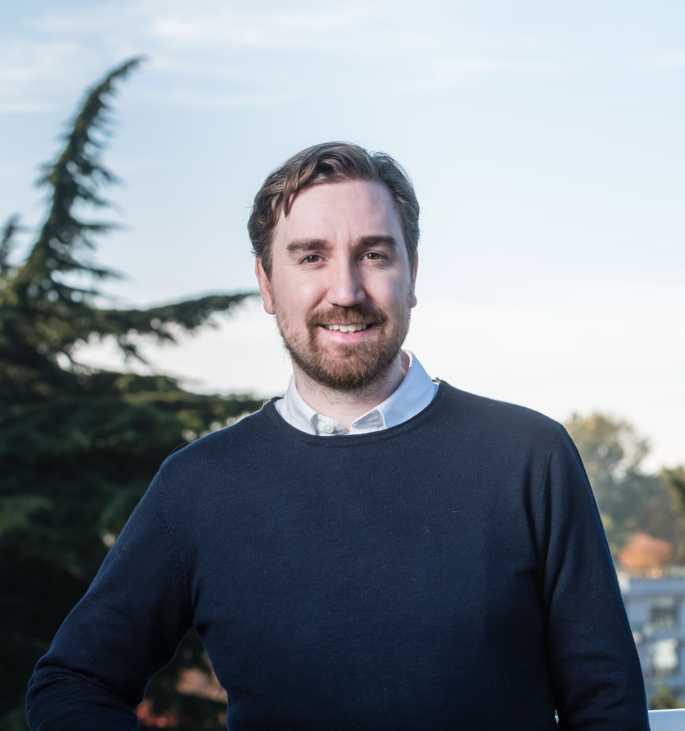

It’s me!

**Jonathan Graves**

- Associate Professor of Teaching, Vancouver School of Economics, UBC
- Undergraduate Director (Curriculum and Students)
- Co-Principal Investigator, PrAxIs Project

## Frustation!

- AI is overwhelming sold in higher education as a way to “save time” and “automate tasks” for students and faculty.
- Or: it’s a way to “learn better” or “more efficienctly” by using it as a tool for studying, writing, etc.

> But: these are *educational* uses for AI. They are not about *economics* or *sociology* or our disciplines. They are about using AI as a general-purpose tool, not as a tool for *doing* economics.

If you look at how actual economists and researchers are using AI tools, the transformative applications are *not* about writing emails faster.

- The really powerful applications are about using AI as a way to do better economics (or sociology, or history), not just to do economics faster.
- We call this **constructing knowledge** since it means using AI in a way that a discipline recognizes as new information.

This was what we wanted to address.

## Our pitch: Have you ever…

- Wanted to teach students that AI tools can **do more** than write essays for them?
- Tried to incorporate machine learning into a **humanities or social science** course and run into the prerequisite wall?
- Wished your students could engage with AI tools *as practitioners of their discipline*, not as passive users?

## This workshop

In this workshop, I have two main goals:

1. To **demonstrate** how we can use AI tools in this constructive way, through demonstrating implementations of two modules from our PrAxIs project.
2. To share the **pedagogical approach** we took in designing these modules, and help you brainstorm how you could apply it in your own courses and disciplines.

## Two gaps

1. **Students see AI as a black box.**

Disconnected from the disciplinary training they’re already doing.

2. **AI literacy taught only in CS courses doesn’t transfer.**

And most Arts majors face prerequisite walls that prevent them from taking those courses anyway.

**The result:** *students who *use* AI tools without understanding them; and who can’t critically evaluate AI-driven research in their own field.*

## The objective

The overaching goal of this project is to show students (and faculty) that:

1. AI can be used to **construct knowledge** in their specific domain, not just as general-purpose tools.
2. AI tools are **more useful** and **more powerful** when embedded in the disciplinary questions and methods they already know.
3. AI tools are **not hard** to use once you understand the basics of how they work and how they connect to familiar concepts.

## Knowledge construction and AI

Our argument is that AI tools in academia are (at their best) tools that allow us to construct knowledge in new ways:

1. **Scale**: AI tools that increase the scale of what an individual can do, through automation or machine assistance.
2. **Perspective**: AI tools that give us new perspectives that are fundamentally different from human perspectives, allowing us to study new kinds of relationships.
   - These perspectives are not necessarily “better” or worse than human perspectives, just different.
   - They also can be automated and systematically varied to study how perspectives shape the knowledge we construct.

We highlight both of these kinds of applications, but think (2) is more important.

## The classroom challenge

- How do we bring these kinds of (often complex) tools into the classroom?
- How do we deal with different technical backgrounds?
- How do we avoid creating unequal knowledge access based on tool access?

## AI tools are statistical tools you already teach

For economics, and other quantitative social science this is not a stretch:

| What CS calls it | What we already teach |
| --- | --- |
| Next-token prediction (LLM s) | Conditional probability over a vocabulary |
| Sentiment classifier | Logistic / multinomial classification on text features |
| Word embeddings | Dimension-reduced vector representation |
| Temperature | Softmax sharpness parameter |
| Confidence score | Predicted probability for the top class |

Not new statistical concepts; familiar ones, just in a new domain.

## What is Praxis?

- *Open educational resource library*: hands-on Jupyter modules and accompanying website with rendered notebooks, documentation, and teaching guides.
  - Builds on an econometrics-focused project called [COMET](https://comet.arts.ubc.ca/): https://comet.arts.ubc.ca/
- *Sponsored by a UBC TLEF grant*: developed mostly by undergraduate research assistants under the supervision of faculty leads, with the goal of including material from Arts, Humanities, and Social Sciences disciplines.
  - Includes material from economics, sociology, political science, history, ancient student, family studies.
- **Open source, CC-BY-NC-SA**: fork-and-adapt encouraged.

## What makes these *teaching* tools, not tech demos or tools

- **Disciplinary question first, technique second**: not the other way around
- **Theoretical scaffolding before the code**: students understand the math and rationale before they run it
- **“Try it yourself” cells at decision points**: We encourage discussion and class activity
- **Discussion prompts that connect the technique back to statistics and Economics that students already know**

## Remainder of this workshop

Walk though of 1 (maybe 2?) modules from our Praxis library, showing specific applications of our pedagogical approach.

1. Module 1: **Do autocratic constitutions sound different**? (Political Economy)
2. Module 2: **From next-word prediction to predicting markets** (Econometrics)

# Demonstration

## Module 1: Do autocratic constitutions sound different?

- **Question:** is the language of authoritarian constitutions distinguishable from democratic ones?
- **Data:** Comparative Constitutions Project 193 national constitutions, classified by V-Dem’s *Regimes of the World* index
- **Method:** TF-IDF-weighted Word2Vec embeddings, cosine similarity, Cohen’s d + Welch’s t-test
- **Course context:** Political Economy

## Authoritarian regimes use democratic vocabulary more than democracies do

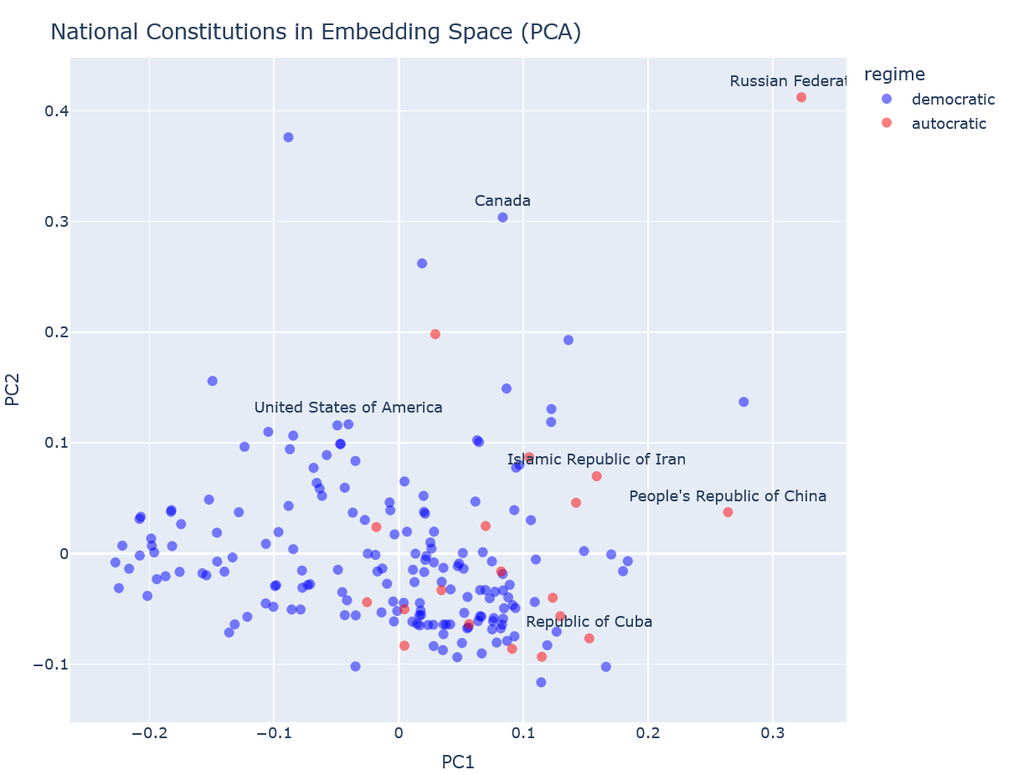

| Word | Cohen’s *d* | *p-value* |
| --- | --- | --- |
| democracy | 0.886 | 0.0003 |
| equality | 0.846 | 0.0031 |
| freedom | 0.773 | 0.0043 |

Positive *d* → closer to autocratic constitutions

The constitutions claiming to value democracy most heavily aren’t the democratic ones.

## Module 2: From next-word prediction to predicting markets

- **Question:** can the same conditional-distribution machinery used for next-word prediction → sentiment classification → linear regression on stock returns
- **Data:** Financial PhraseBank (expert-labeled) + Twitter financial news sentiment (2019)
- **Method:** pretrained RoBERTa for sentiment, linear regression on returns
- **Course context:** Data in Economics

## Sentiment, prediction and stock returns

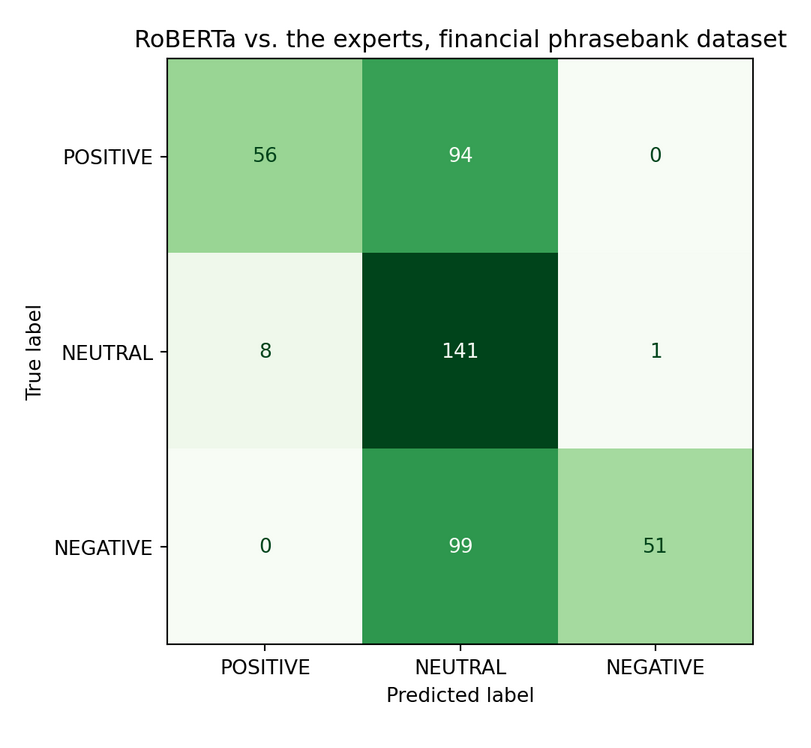

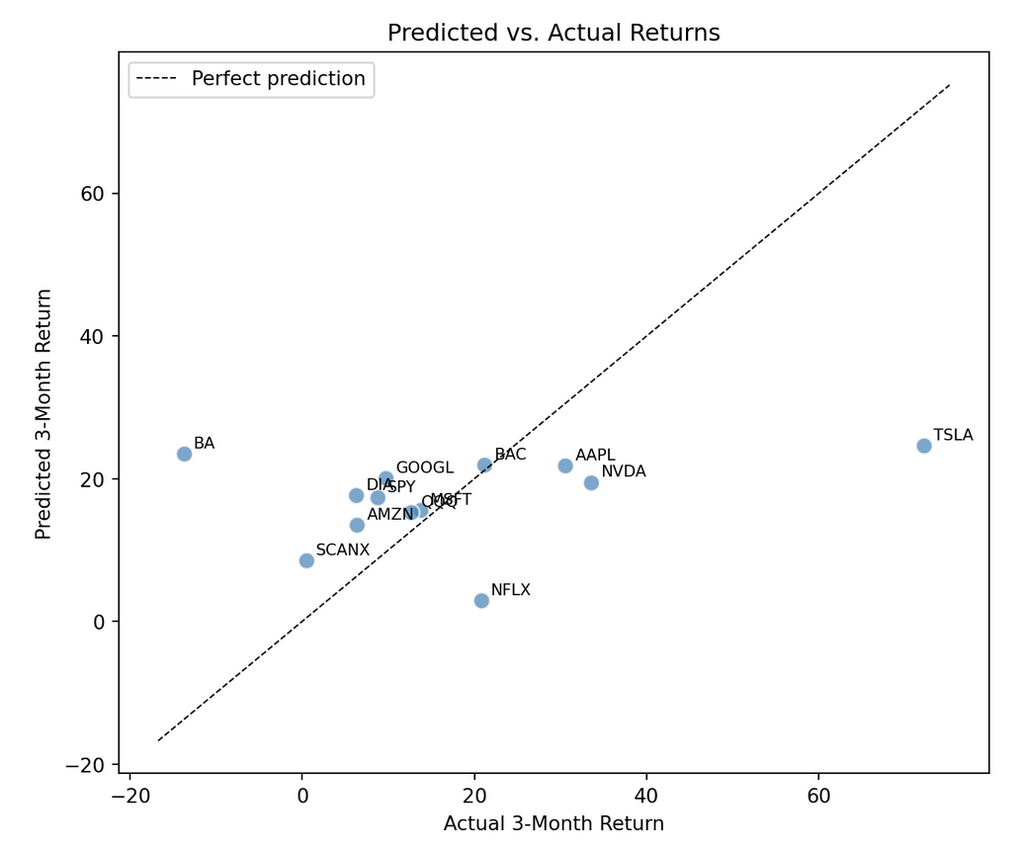

## Three ways to use Praxis

1. **Read the rendered notebooks online**  
   Every notebook is fully rendered with code output on the Praxis site. Students read in a browser, no Python environment needed.
2. **Launch interactively**  
   JupyterOpen (UBC), Syzygy (PIMS), or Google Colab. One-click links from the site.
3. **Fork and adapt**  
   CC-BY-NC-SA. The `.qmd` source is on GitHub. Clone and modify for your own course.

## Beyond economics

**SOCI 415** — Network analysis (Family Networks, Kinship and Chinese Dynasties)

**SOCI 280** — Sentiment analysis & disinformation (BERT) and Propaganda

**HIST 414** — Text embeddings & historical text analysis (Legal stance on Chinese immigrants in BC)

**AMNE 376** — Image embeddings & computer vision (Richter’s *Kouroi*, Greek antiquity)

Same pedagogy, different disciplines.

## Demonstration time

[figure not shown]

Political Economy - https://tinyurl.com/cTreeDemo2

[figure not shown]

Data in Economics QR code - https://tinyurl.com/ctreeDemo1

Figure 1: Demonstration QR codes - links to Google colab

## Lessons learned

- A real power of AI for teaching is the ability to create **new forms of knowledge** that previously were very difficult to even describe, let alone perform.
- AI literacy needs to be embedded in the disciplinary questions and methods students already know, not taught as a separate technical skill.
  - To be a critical user and consumer of AI tools, you need to understand how the knowledge they are creating is connected to the questions and methods you are using.
- Students are highly capable and motivated to use, create, and iterate on these tools when given the opportunity and support. The biggest obstacle is fear.

## Thank you · Get involved

**Contact**

- General: comet.project@ubc.ca
- Jonathan Graves: jonathan.graves@ubc.ca
- Laura Nelson: laura.k.nelson@ubc.ca

**Acknowledgements**

UBC TLEF · Vancouver School of Economics · Department of Sociology · CCSS

[figure not shown]

The Praxis Project and UBC are located on the traditional, ancestral and unceded territory of the xʷməθkʷəy̓əm (Musqueam) and Sḵwx̱wú7mesh (Squamish) peoples.

[figure not shown]

PrAxIs UBC · ubcecon.github.io/praxis-ubc